# Project Python Foundations: FoodHub Data Analysis

### Context

The number of restaurants in New York is increasing day by day. Lots of students and busy professionals rely on those restaurants due to their hectic lifestyles. Online food delivery service is a great option for them. It provides them with good food from their favorite restaurants. A food aggregator company FoodHub offers access to multiple restaurants through a single smartphone app.

The app allows the restaurants to receive a direct online order from a customer. The app assigns a delivery person from the company to pick up the order after it is confirmed by the restaurant. The delivery person then uses the map to reach the restaurant and waits for the food package. Once the food package is handed over to the delivery person, he/she confirms the pick-up in the app and travels to the customer's location to deliver the food. The delivery person confirms the drop-off in the app after delivering the food package to the customer. The customer can rate the order in the app. The food aggregator earns money by collecting a fixed margin of the delivery order from the restaurants.

### Objective

The food aggregator company has stored the data of the different orders made by the registered customers in their online portal. They want to analyze the data to get a fair idea about the demand of different restaurants which will help them in enhancing their customer experience. Suppose you are hired as a Data Scientist in this company and the Data Science team has shared some of the key questions that need to be answered. Perform the data analysis to find answers to these questions that will help the company to improve the business.

### Data Description

The data contains the different data related to a food order. The detailed data dictionary is given below.

### Data Dictionary

- order_id: Unique ID of the order
- customer_id: ID of the customer who ordered the food
- restaurant_name: Name of the restaurant
- cuisine_type: Cuisine ordered by the customer
- cost_of_the_order: Cost of the order
- day_of_the_week: Indicates whether the order is placed on a weekday or weekend (The weekday is from Monday to Friday and the weekend is Saturday and Sunday)
- rating: Rating given by the customer out of 5
- food_preparation_time: Time (in minutes) taken by the restaurant to prepare the food. This is calculated by taking the difference between the timestamps of the restaurant's order confirmation and the delivery person's pick-up confirmation.
- delivery_time: Time (in minutes) taken by the delivery person to deliver the food package. This is calculated by taking the difference between the timestamps of the delivery person's pick-up confirmation and drop-off information

### Let us start by importing the required libraries

```python
# Installing the libraries with the specified version.
!pip install numpy==1.25.2 pandas==1.5.3 matplotlib==3.7.1 seaborn==0.13.1 -q --user
```

**Note**:

- After running the above cell, kindly restart the runtime (for Google Colab) or notebook kernel (for Jupyter Notebook), and run all cells sequentially from the next cell.
- On executing the above line of code, you might see a warning regarding package dependencies. This error message can be ignored as the above code ensures that all necessary libraries and their dependencies are maintained to successfully execute the code in **this notebook**.

```python
# import libraries for data manipulation
import numpy as np
import pandas as pd

# import libraries for data visualization
import matplotlib.pyplot as plt
import seaborn as sns
```

### Understanding the structure of the data

```python
# uncomment and run the below code snippets if the dataset is present in the Google Drive
from google.colab import drive
drive.mount('/content/drive/')
```

```python
# Write your code here to read the data
path="/content/drive/MyDrive/Colab Notebooks/FoodHub/foodhub_order.csv"
data = pd.read_csv(path)
# copying data to another variable to avoid any changes to original data
df = data.copy()
```

```python
# Write your code here to view the first 5 rows
df.head()
```

|  | order_id | customer_id | restaurant_name | cuisine_type | cost_of_the_order | day_of_the_week | rating | food_preparation_time | delivery_time |
| --- | --- | --- | --- | --- | --- | --- | --- | --- | --- |
| 0 | 1477147 | 337525 | Hangawi | Korean | 30.75 | Weekend | Not given | 25 | 20 |
| 1 | 1477685 | 358141 | Blue Ribbon Sushi Izakaya | Japanese | 12.08 | Weekend | Not given | 25 | 23 |
| 2 | 1477070 | 66393 | Cafe Habana | Mexican | 12.23 | Weekday | 5 | 23 | 28 |
| 3 | 1477334 | 106968 | Blue Ribbon Fried Chicken | American | 29.20 | Weekend | 3 | 25 | 15 |
| 4 | 1478249 | 76942 | Dirty Bird to Go | American | 11.59 | Weekday | 4 | 25 | 24 |

### **Question 1:** How many rows and columns are present in the data? [0.5 mark]

```python
# Write your code here
df.shape
```

```
(1898, 9)
```

### Observations: By using the .shape attribute on the data DataFrame, we can see that it contains 1,898 rows and 9 columns.

### **Question 2:** What are the datatypes of the different columns in the dataset? (The info() function can be used) [0.5 mark]

```python
# Write your code here
df.info()
```

```
<class 'pandas.core.frame.DataFrame'>
RangeIndex: 1898 entries, 0 to 1897
Data columns (total 9 columns):
 #   Column                 Non-Null Count  Dtype
---  ------                 --------------  -----
 0   order_id               1898 non-null   int64
 1   customer_id            1898 non-null   int64
 2   restaurant_name        1898 non-null   object
 3   cuisine_type           1898 non-null   object
 4   cost_of_the_order      1898 non-null   float64
 5   day_of_the_week        1898 non-null   object
 6   rating                 1898 non-null   object
 7   food_preparation_time  1898 non-null   int64
 8   delivery_time          1898 non-null   int64
dtypes: float64(1), int64(4), object(4)
memory usage: 133.6+ KB
```

#### Observations: The dataset contains 9 columns with the following data types:

**Data Type: int64** *order_id, customer_id, food_preparation_time, and delivery_time*

**Data Type: float64** *cost_of_the_order*

**Data Type: object** *restaurant_name, cuisine_type, day_of_the_week, and rating*

### **Question 3:** Are there any missing values in the data? If yes, treat them using an appropriate method. [1 mark]

```python
# Write your code here
# Copy the df to df1 and make necessary changes to reflect rating field missing values as NaN
df1 = df.copy()
# Make sure rating field reflects the change in the Dtype
print(df1.info())
```

```
<class 'pandas.core.frame.DataFrame'>
RangeIndex: 1898 entries, 0 to 1897
Data columns (total 9 columns):
 #   Column                 Non-Null Count  Dtype
---  ------                 --------------  -----
 0   order_id               1898 non-null   int64
 1   customer_id            1898 non-null   int64
 2   restaurant_name        1898 non-null   object
 3   cuisine_type           1898 non-null   object
 4   cost_of_the_order      1898 non-null   float64
 5   day_of_the_week        1898 non-null   object
 6   rating                 1898 non-null   object
 7   food_preparation_time  1898 non-null   int64
 8   delivery_time          1898 non-null   int64
dtypes: float64(1), int64(4), object(4)
memory usage: 133.6+ KB
None
```

#### Observations: The data contains no missing values, but it it does contain a column, 'rating', that is listed as a string that should be a float. Later, this column will be modified.

### **Question 4:** Check the statistical summary of the data. What is the minimum, average, and maximum time it takes for food to be prepared once an order is placed? [2 marks]

```python
# Write your code here
df1.describe()
```

|  | order_id | customer_id | cost_of_the_order | food_preparation_time | delivery_time |
| --- | --- | --- | --- | --- | --- |
| count | 1.898000e+03 | 1898.000000 | 1898.000000 | 1898.000000 | 1898.000000 |
| mean | 1.477496e+06 | 171168.478398 | 16.498851 | 27.371970 | 24.161749 |
| std | 5.480497e+02 | 113698.139743 | 7.483812 | 4.632481 | 4.972637 |
| min | 1.476547e+06 | 1311.000000 | 4.470000 | 20.000000 | 15.000000 |
| 25% | 1.477021e+06 | 77787.750000 | 12.080000 | 23.000000 | 20.000000 |
| 50% | 1.477496e+06 | 128600.000000 | 14.140000 | 27.000000 | 25.000000 |
| 75% | 1.477970e+06 | 270525.000000 | 22.297500 | 31.000000 | 28.000000 |
| max | 1.478444e+06 | 405334.000000 | 35.410000 | 35.000000 | 33.000000 |

#### Observations: The describe attribute revealed that the time it takes to prepare an order ranges from a minimum of 20 minutes to a maxium of 35 minutes with an average time of 27.4 minutes.

### **Question 5:** How many orders are not rated? [1 mark]

```python
# Write the code here
# print(df['rating'].unique())
# Count the number of orders with missing (NaN) ratings
not_given = df1['rating'].eq('Not given').sum()

# Display the result
print(f"Number of orders marked 'Not given': {not_given}")
```

```
Number of orders marked 'Not given': 736
```

#### Observations: In the original dataset, when customers did not leave a rating, the rating field contained the string value "Not given". The data reveals that 736 orders in the dataset were not rated. Users did not leave a rating for 39% of orders.

### Exploratory Data Analysis (EDA)

### **Question 6:** Explore all the variables and provide observations on their distributions. (Generally, histograms, boxplots, countplots, etc. are used for univariate exploration.) [9 marks]

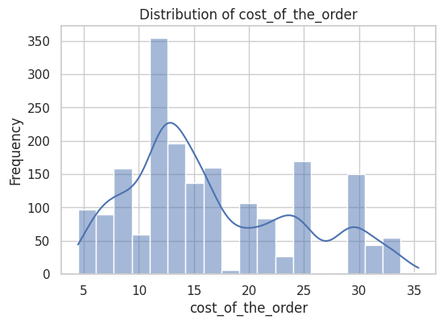

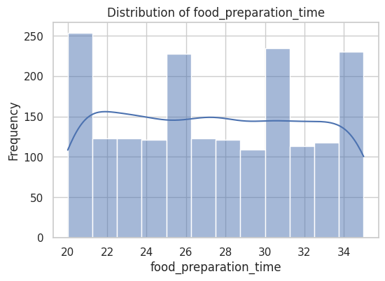

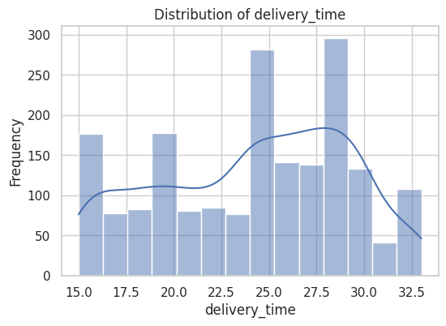

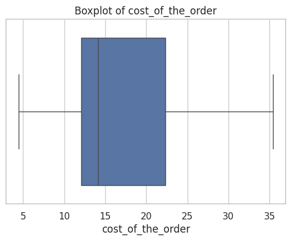

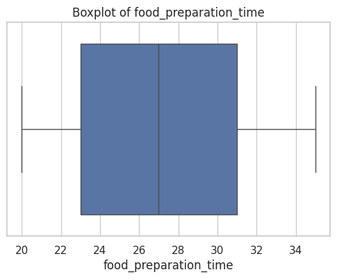

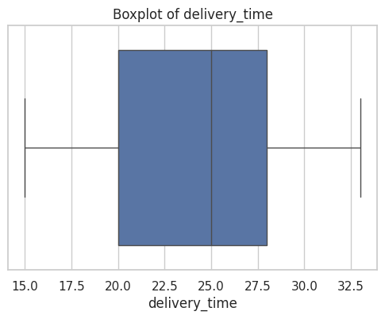

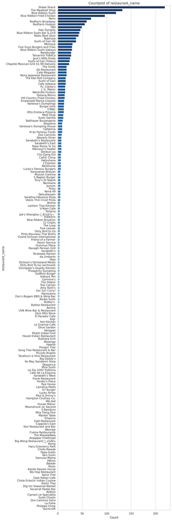

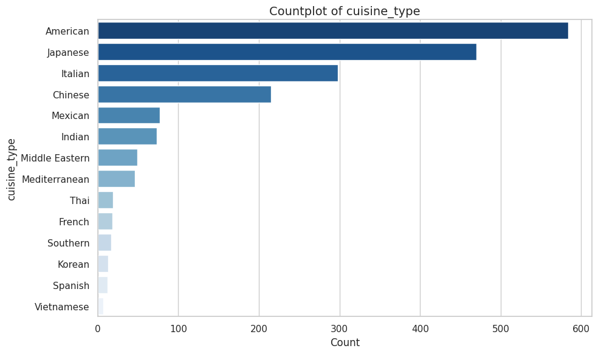

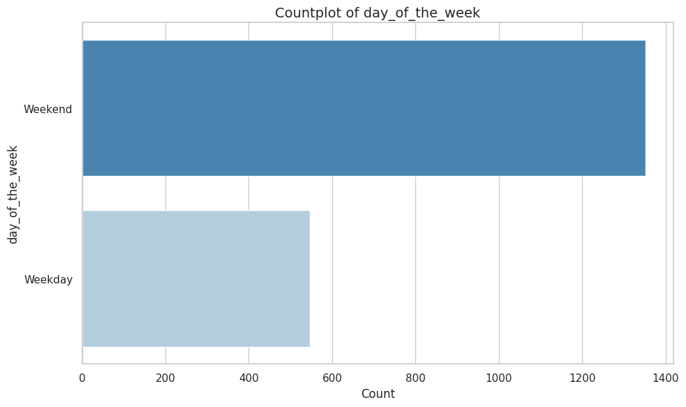

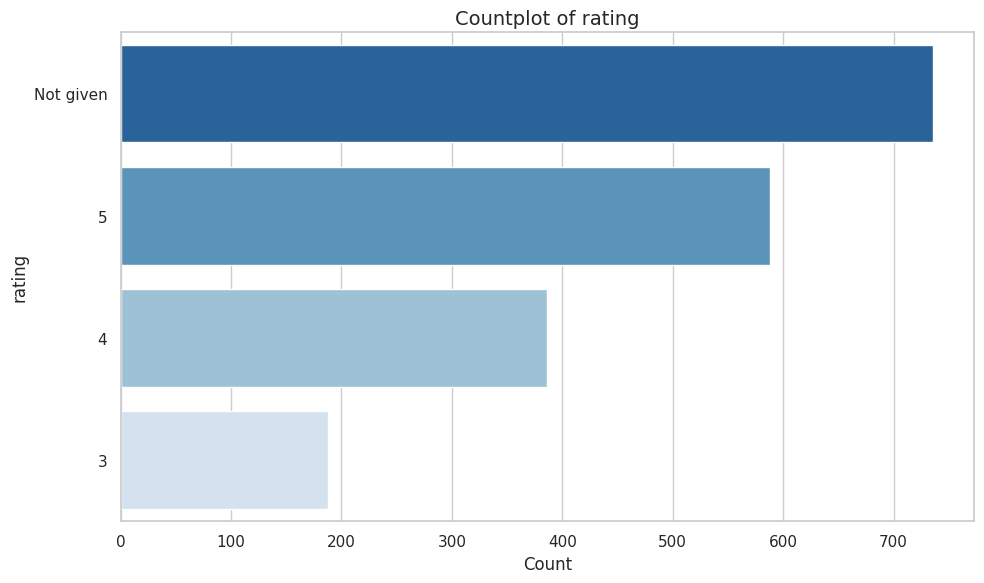

```python
# Write the code here

# Optional: Set a clean style
sns.set(style='whitegrid')

# Separate numerical and categorical columns
numerical_cols = ['cost_of_the_order', 'food_preparation_time', 'delivery_time']
categorical_cols = ['restaurant_name', 'cuisine_type', 'day_of_the_week', 'rating']

# 1. Histograms for numerical features
for col in numerical_cols:
    plt.figure(figsize=(6, 4))
    sns.histplot(df1[col], kde=True)
    plt.title(f'Distribution of {col}')
    plt.xlabel(col)
    plt.ylabel('Frequency')
    plt.show()

# 2. Boxplots for numerical features
for col in numerical_cols:
    plt.figure(figsize=(6, 4))
    sns.boxplot(x=df1[col])
    plt.title(f'Boxplot of {col}')
    plt.xlabel(col)
    plt.show()

# 3. Countplots for categorical features
for col in categorical_cols:
    # ***readability enhancementts ***
    unique_count = df1[col].nunique()
    height = min(max(6, unique_count * 0.4), 30)  # Cap height for huge categories

    plt.figure(figsize=(10, height))

    # Horizontal bars for better label visibility
    sns.countplot(y=df1[col], order=df1[col].value_counts().index, palette='Blues_r')

    plt.title(f'Countplot of {col}', fontsize=14)
    plt.xlabel('Count')
    plt.ylabel(col)
    plt.tight_layout()
    plt.show()
    # ***readability enhancementts ***
    #plt.figure(figsize=(12, 10))
    #sns.countplot(y=df1[col], order=df1[col].value_counts().index)
    #plt.title(f'Countplot of {col}')
    #plt.xlabel('Count')
    #plt.ylabel(col)
    #plt.show()
```

### **Question 7**: Which are the top 5 restaurants in terms of the number of orders received? [1 mark]

```python
# Write the code here
# Count orders per restaurant and display top 5
top_5_counts = df1['restaurant_name'].value_counts().head(5)

# Display the result
print(top_5_counts)
```

```
Shake Shack                  219
The Meatball Shop            132
Blue Ribbon Sushi            119
Blue Ribbon Fried Chicken     96
Parm                          68
Name: restaurant_name, dtype: int64
```

#### Observations: The data reveals that Shake Shack is the most popular restaurant, receiving 219 orders. It is followed by The Meatball Shop (132 orders), Blue Ribbon Sushi (119 orders), Blue Ribbon Fried Chicken (96 orders), and Parm (68 orders). Given that two of the top five are American cuisine, this suggests a possible preference for American food in this dataset.

### **Question 8**: Which is the most popular cuisine on weekends? [1 mark]

```python
# Write the code here
# Filter for weekend rows
weekend_orders = df1[df1['day_of_the_week'] == 'Weekend']

# Find the most popular cuisine
most_popular_cuisine_weekend = weekend_orders['cuisine_type'].value_counts().idxmax()

print("Most popular cuisine on weekends:", most_popular_cuisine_weekend)
```

```
Most popular cuisine on weekends: American
```

#### Observations: The most popular cuisine on the weekends is American.

### **Question 9**: What percentage of the orders cost more than 20 dollars? [2 marks]

```python
# Write the code here
# Total number of orders
total_orders = df1.shape[0]

# Number of orders costing more than $20
orders_over_20 = df1[df1['cost_of_the_order'] > 20].shape[0]

# Calculate the percentage
percentage_over_20 = (orders_over_20 / total_orders) * 100

# Display the result
print(f"Percentage of orders costing more than $20: {percentage_over_20:.2f}%")
```

```
Percentage of orders costing more than $20: 29.24%
```

#### Observations: In this dataset, 29% of orders are greater than $20.

### **Question 10**: What is the mean order delivery time? [1 mark]

```python
# Write the code here
mean_delivery_time = df1['delivery_time'].mean()
print(mean_delivery_time)
```

```
24.161749209694417
```

#### Observations: The average delivery time across all orders in the dataset is approximately 24 minutes, indicating the typical wait time experienced by customers.

### **Question 11:** The company has decided to give 20% discount vouchers to the top 3 most frequent customers. Find the IDs of these customers and the number of orders they placed. [1 mark]

```python
# Write the code here
# Write the code here
# Find the top 3 most frequent customers by number of orders
top_3_customers = df1['customer_id'].value_counts().head(3).reset_index()
top_3_customers.columns = ['customer_id', 'order_count']

# Display the result
print(top_3_customers)
```

```
   customer_id  order_count
0        52832           13
1        47440           10
2        83287            9
```

#### Observations: The data shows that Customer ID 52832 placed the highest number of orders (13), followed by Customer ID 47440 with 10 orders, and Customer ID 83287 with 9 orders. These customers demonstrate a high level of engagement with the platform and are ideal recipients for a loyalty incentive like a 20% discount voucher.

### **Question 12**: Perform a multivariate analysis to explore relationships between the important variables in the dataset. (It is a good idea to explore relations between numerical variables as well as relations between numerical and categorical variables) [10 marks]

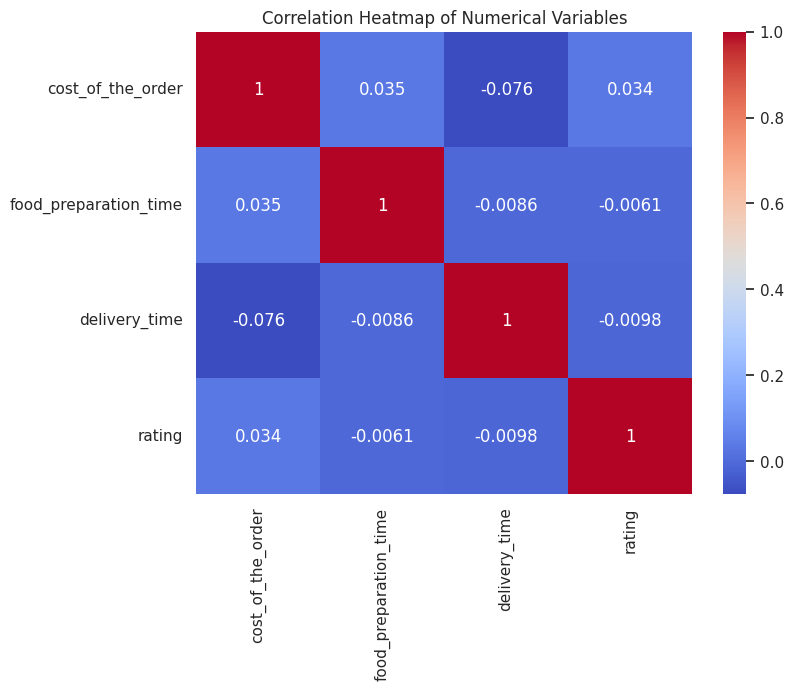

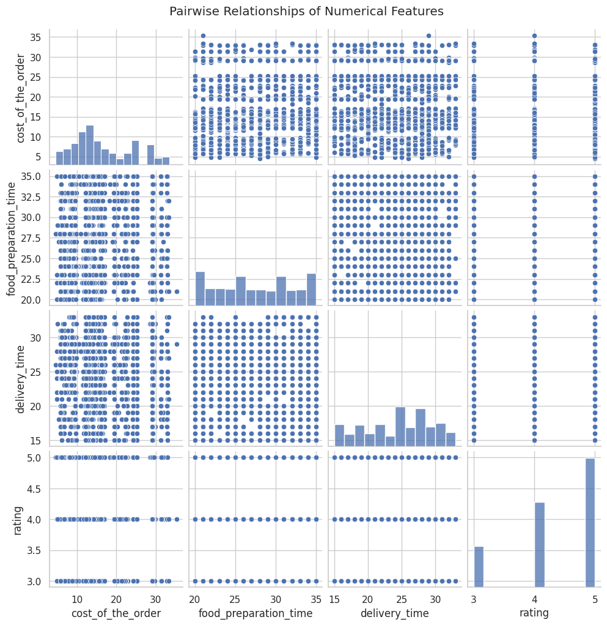

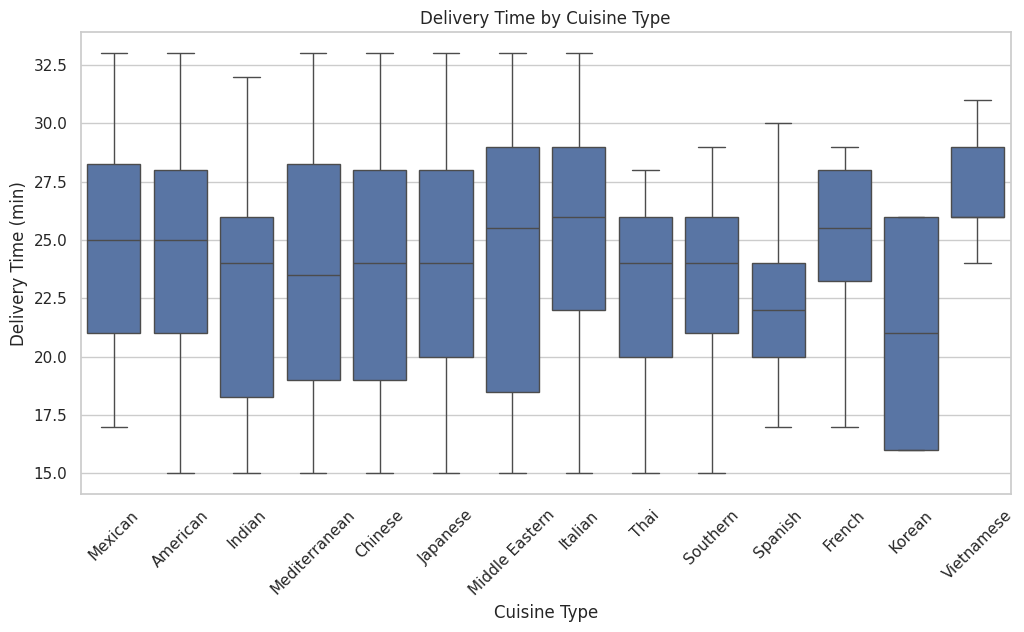

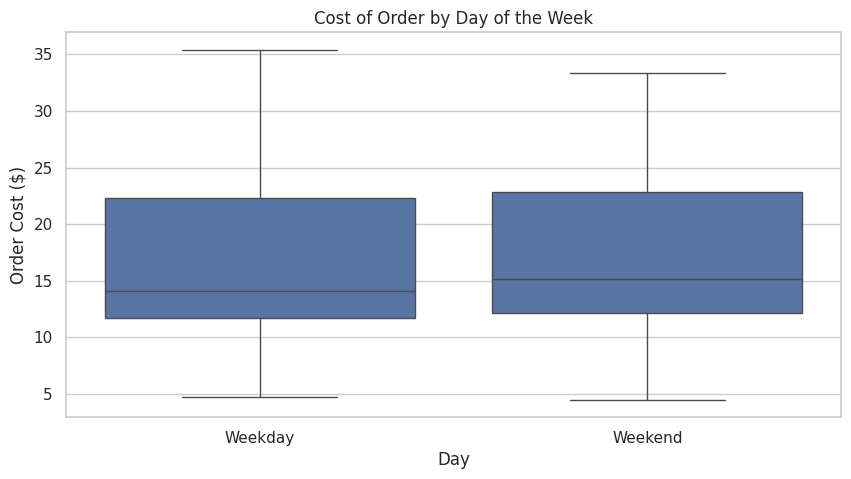

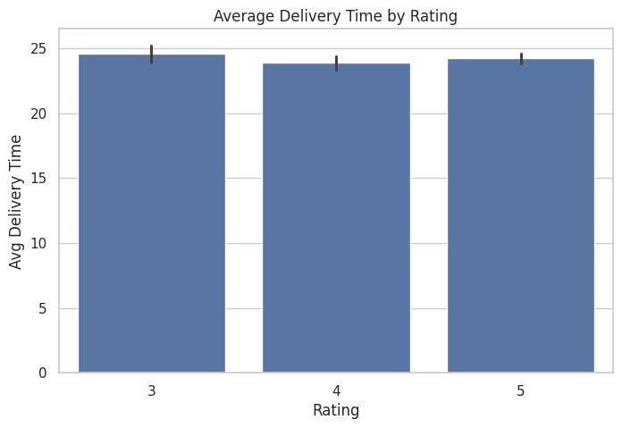

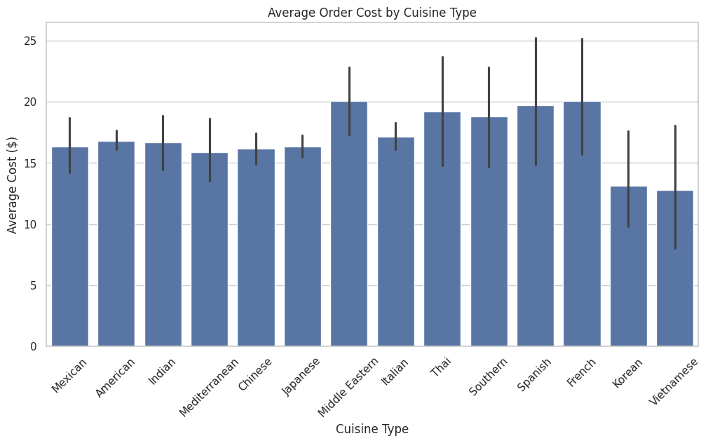

```python
# Ensure clean visual style
sns.set(style='whitegrid')

df2 = df1.copy()
# Dropping the rows where the rating is not included and excluding them from analysis
df2 = df2[df2['rating'] != 'Not given']
# Converting the values that remain to nummeric for analysis
df2['rating'] = pd.to_numeric(df2['rating'], errors='coerce')


# 2. Define important numerical and categorical variables
numerical_cols = ['cost_of_the_order', 'food_preparation_time', 'delivery_time', 'rating']
categorical_cols = ['cuisine_type', 'day_of_the_week']

# 3. Correlation Heatmap
plt.figure(figsize=(8, 6))
sns.heatmap(df2[numerical_cols].corr(), annot=True, cmap='coolwarm')
plt.title('Correlation Heatmap of Numerical Variables')
plt.show()

# 4. Pairplot of Numerical Variables (drop NaN in rating to avoid issues)
sns.pairplot(df2[numerical_cols].dropna())
plt.suptitle('Pairwise Relationships of Numerical Features', y=1.02)
plt.show()

# 5. Boxplot: Delivery Time by Cuisine Type
plt.figure(figsize=(12, 6))
sns.boxplot(x='cuisine_type', y='delivery_time', data=df2)
plt.xticks(rotation=45)
plt.title('Delivery Time by Cuisine Type')
plt.xlabel('Cuisine Type')
plt.ylabel('Delivery Time (min)')
plt.show()

# 6. Boxplot: Cost of Order by Day of the Week
plt.figure(figsize=(10, 5))
sns.boxplot(x='day_of_the_week', y='cost_of_the_order', data=df2)
plt.title('Cost of Order by Day of the Week')
plt.xlabel('Day')
plt.ylabel('Order Cost ($)')
plt.show()

# 7. Barplot: Average Delivery Time by Rating
plt.figure(figsize=(8, 5))
sns.barplot(x='rating', y='delivery_time', data=df2)
plt.title('Average Delivery Time by Rating')
plt.xlabel('Rating')
plt.ylabel('Avg Delivery Time')
plt.show()

# 8. Barplot: Average Cost by Cuisine Type
plt.figure(figsize=(12, 6))
sns.barplot(x='cuisine_type', y='cost_of_the_order', data=df2)
plt.xticks(rotation=45)
plt.title('Average Order Cost by Cuisine Type')
plt.xlabel('Cuisine Type')
plt.ylabel('Average Cost ($)')
plt.show()
```

#### Observations: After removing rows with non-informative "Not given" ratings and converting the remaining ratings to numeric values, the correlation heatmap reveals that the numerical variables in the dataset exhibit very weak linear relationships with one another.

1. The delivery time shows a slight negative correlation with cost of the order (-0.076), suggesting that higher-cost orders may be delivered marginally faster, though this relationship is minimal.
2. The rating variable demonstrates a weak positive correlation with cost of the order (0.034), indicating that customers may tend to rate more expensive orders slightly higher. However, the correlation is not strong enough to suggest a consistent pattern.
3. Correlations between rating and both food preparation time and delivery time are nearly zero, implying that customer feedback is not significantly influenced by logistical metrics alone.

These findings indicate that customer ratings are likely driven by factors not captured in the dataset, such as food quality, customer service, or packaging. While the cleaning step improved data integrity, the weak correlations suggest limited predictive value of the current numerical features on customer satisfaction.

Additional observations include support previous conclusions, but add the following:

4. Distribution: The rating variable is heavily skewed toward the higher end, with the majority of ratings being 4 or 5.
5. Cost of the Order shows a broad spread, with a slight positive skew. However, there is no visible linear trend when plotted against delivery time or preparation time
6. Inter-variable Relationships: Scatter plots reveal no strong or obvious linear trends between most variable pairs. This visual inspection confirms the earlier correlation analysis—no significant pairwise dependencies exist among the numeric features.

### **Question 13:** The company wants to provide a promotional offer in the advertisement of the restaurants. The condition to get the offer is that the restaurants must have a rating count of more than 50 and the average rating should be greater than 4. Find the restaurants fulfilling the criteria to get the promotional offer. [3 marks]

```python
df3 = df1.copy()

# Correct: Drop "Not given" ratings
df3 = df3[df3['rating'] != 'Not given']
# Converting the values that remain to nummeric for analysis
df3['rating'] = pd.to_numeric(df2['rating'], errors='coerce')

# Group by restaurant and compute count and average of valid ratings
restaurant_ratings = df3.groupby('restaurant_name')['rating'].agg(['count', 'mean']).reset_index()

# Apply the promotional offer conditions
eligible_restaurants = restaurant_ratings[(restaurant_ratings['count'] > 50) & (restaurant_ratings['mean'] > 4)]

# Display eligible restaurants
print(eligible_restaurants)
```

```
               restaurant_name  count      mean
16   Blue Ribbon Fried Chicken     64  4.328125
17           Blue Ribbon Sushi     73  4.219178
117                Shake Shack    133  4.278195
132          The Meatball Shop     84  4.511905
```

#### Observations: To identify restaurants eligible for a promotional offer, we filtered for those that had:More than 50 ratings, and an average rating greater than 4.0. The analysis revealed four restaurants meeting both criteria. The Meatball Shop not only qualifies but also has the highest average rating (4.51) among the eligible restaurants, suggesting a strong customer satisfaction trend. Shake Shack, with 133 ratings, stands out as the most frequently rated restaurant, indicating high engagement and popularity. Both Blue Ribbon franchises also qualify, reflecting consistent customer satisfaction across different food offerings under the same brand.

### **Question 14:** The company charges the restaurant 25% on the orders having cost greater than 20 dollars and 15% on the orders having cost greater than 5 dollars. Find the net revenue generated by the company across all orders. [3 marks]

```python
# Write the code here
# Define commission logic using conditions
def calculate_revenue(order_cost):
    if order_cost > 20:
        return order_cost * 0.25
    elif order_cost > 5:
        return order_cost * 0.15
    else:
        return 0

# Apply revenue calculation to each row
df1['company_revenue'] = df1['cost_of_the_order'].apply(calculate_revenue)

# Calculate total revenue
total_revenue = df1['company_revenue'].sum()

# Display result
print(f"Total revenue generated by the company: ${total_revenue:.2f}")
```

```
Total revenue generated by the company: $6166.30
```

#### Observations: Based on the company’s tiered commission structure— 25% on orders above $20 and 15% on orders above $5— the total net revenue generated from all qualifying orders in the dataset is $6,166.30. This approach allows the company to maximize revenue from high-value orders while still capturing earnings from mid-range transactions. It highlights that a significant portion of revenue is driven by customers who place larger orders, suggesting that promoting high-value meals or bundles could further enhance profitability.

### **Question 15:** The company wants to analyze the total time required to deliver the food. What percentage of orders take more than 60 minutes to get delivered from the time the order is placed? (The food has to be prepared and then delivered.) [2 marks]

```python
# Write the code here


# Step 1: Calculate total time for each order
df1['total_time'] = df1['food_preparation_time'] + df1['delivery_time']

# Step 2: Calculate total number of orders
total_orders = df1.shape[0]

# Step 3: Count how many orders took more than 60 minutes
orders_over_60 = df1[df1['total_time'] > 60].shape[0]

# Step 4: Calculate percentage
percentage_over_60 = (orders_over_60 / total_orders) * 100

# Step 5: Display result
print(f"Percentage of orders taking more than 60 minutes: {percentage_over_60:.2f}%")
```

```
Percentage of orders taking more than 60 minutes: 10.54%
```

#### Observations: Approximately 10.54% of all orders in the dataset took more than 60 minutes from the time the order was placed to final delivery (including both food preparation and delivery time). This suggests that roughly 1 in 10 orders exceed an hour, which could impact customer satisfaction, especially during peak times.

### **Question 16:** The company wants to analyze the delivery time of the orders on weekdays and weekends. How does the mean delivery time vary during weekdays and weekends? [2 marks]

```python
# Write the code here
# Group by 'day_of_the_week' and calculate mean delivery time
mean_delivery_by_daytype = df1.groupby('day_of_the_week')['delivery_time'].mean().round(2)

# Display the result
print(mean_delivery_by_daytype)
```

```
day_of_the_week
Weekday    28.34
Weekend    22.47
Name: delivery_time, dtype: float64
```

```python
!jupyter nbconvert --to html Copy\ of\ PYF_Project_Learner_Notebook_Full_Code_orig.ipynb
```

```
[NbConvertApp] Converting notebook Copy of PYF_Project_Learner_Notebook_Full_Code_orig.ipynb to html
[NbConvertApp] WARNING | Alternative text is missing on 16 image(s).
[NbConvertApp] Writing 1749772 bytes to Copy of PYF_Project_Learner_Notebook_Full_Code_orig.html
```